# Textanalyse mit Wörterbüchern und Sentiments mit `quanteda`

Philipp Meyer, Institut für Politikwissenschaft

19.05.2021, Dictionaries und Sentiment Analysis, Seminar: Quantitative Textanalyse

# 1. Einleitung

Viele QTA-Studien analysieren den "Ton" bzw. *Sentiment* eines Textes. Eine Sentimentanalyse ist daran interessiert, den emotionalen Inhalt eines Text, Facebookpost oder eines Tweet zu analysieren. Ist ein Text positiv oder negativ in Bezug auf ein bestimmtes Thema (z.B. Pro- oder Anti-Brexit)? Ist ein Akteur für oder gegen einen bestimmten politischen Vorschlag?

In diesem Tutorial werden wir die Wörterbuchmethode (**Dictionary approach**) verwenden und Sentiment-Analysen durchführen. Diese Methode hat sich als sehr effizient herausgestellt, z.B. um zu entscheiden, ob eine Rezension auf Amazon positiv oder negativ ist. Sentiment-Analysen sind jedoch nicht für jedes Forschungsproblem geeignet. Zeitungsartikel z.B. können verschiedene und sich wiedersprechende Aussagen und Tonlagen zu einem Thema beinhalten. Die Wahl der Methode ist also immer kontextabhängig zu treffen.

Ein wichtiger Teil dieses Tutorials wird sich mit der Validierung unseres Wörterbuches befassen. Damit möchte ich euch zeigen, wie wichtig es ist, die verwendeten Methoden und gefunden Ergebnisse auf ihre Gültigkeit hin zu überprüfen. Lexika bzw. Wörterbücher zum Beispiel sollten immer an die jeweilige Aufgabe angepasst werden, indem der Kontext der zu interessierenden Kernkonzepte/-wörter untersucht wird.

# 2. Eine Dokument-Feature-Matrix (DFM) erstellen

Die Grundlage für eine dictionary-Analyse ist die Dokument-Feature-Matrix (DFM) bzw. Dokument-Term-Matrix (DTM).

Für dieses Tutorial werden wir nicht den Gerichtskorpus verwenden, da es noch kein etabliertes Wörterbuch für Verfassungsgerichtstexte gibt (**Wink mit dem Zaunpfahl**: Vielleicht ein gutes Thema für eine Hausarbeit?).

Als Alternative werden wir die bereits bekannten Antrittsreden der US Präsidenten aus dem `quanteda`-Paket verwenden (eine Liste aller in `quanteda` gespeicherten Korpora findet ihr hier: quanteda.corpora).

```r
library(quanteda)
library(quanteda.textplots)
library(quanteda.textstats)


inaug_speeches <- data_corpus_inaugural
```

Jetzt erstellen wir eine DTM mittels einer Pipeline:

```r
library(tidyverse)

dtm_speeches <-  inaug_speeches %>%
  tokens(remove_numbers = TRUE, remove_punct = TRUE,remove_symbols = TRUE) %>%
  tokens_remove(pattern = stopwords("english")) %>%
  tokens_tolower() %>%
  dfm() # wir entfernen alle Füllwörter, die Interpunktion, Symbole, Zahlen
dtm_speeches
```

```
## Document-feature matrix of: 59 documents, 9,212 features (92.66% sparse) and 4 docvars.
##                  features
## docs              fellow-citizens senate house representatives among
##   1789-Washington               1      1     2               2     1
##   1793-Washington               0      0     0               0     0
##   1797-Adams                    3      1     0               2     4
##   1801-Jefferson                2      0     0               0     1
##   1805-Jefferson                0      0     0               0     7
##   1809-Madison                  1      0     0               0     0
##                  features
## docs              vicissitudes incident life event filled
##   1789-Washington            1        1    1     2      1
##   1793-Washington            0        0    0     0      0
##   1797-Adams                 0        0    2     0      0
##   1801-Jefferson             0        0    1     0      0
##   1805-Jefferson             0        0    2     0      0
##   1809-Madison               0        0    1     0      1
## [ reached max_ndoc ... 53 more documents, reached max_nfeat ... 9,202 more features ]
```

Ohne Pipeline-Operator sieht der Code wie folgt aus:

```r
inaug_speeches_tokens <- tokens(inaug_speeches, remove_numbers = TRUE, remove_punct = TRUE,remove_symbols = TRUE)

inaug_speeches_tokens <- tokens_remove(inaug_speeches_tokens, pattern = stopwords("english"))
inaug_speeches_tokens <- tokens_tolower(inaug_speeches_tokens)

dtm_speeches <- dfm(inaug_speeches_tokens)

dtm_speeches
```

```
## Document-feature matrix of: 59 documents, 9,212 features (92.66% sparse) and 4 docvars.
##                  features
## docs              fellow-citizens senate house representatives among
##   1789-Washington               1      1     2               2     1
##   1793-Washington               0      0     0               0     0
##   1797-Adams                    3      1     0               2     4
##   1801-Jefferson                2      0     0               0     1
##   1805-Jefferson                0      0     0               0     7
##   1809-Madison                  1      0     0               0     0
##                  features
## docs              vicissitudes incident life event filled
##   1789-Washington            1        1    1     2      1
##   1793-Washington            0        0    0     0      0
##   1797-Adams                 0        0    2     0      0
##   1801-Jefferson             0        0    1     0      0
##   1805-Jefferson             0        0    2     0      0
##   1809-Madison               0        0    1     0      1
## [ reached max_ndoc ... 53 more documents, reached max_nfeat ... 9,202 more features ]
```

Mittels einer einfachen Word cloud können wir unsere DTM inspizieren:

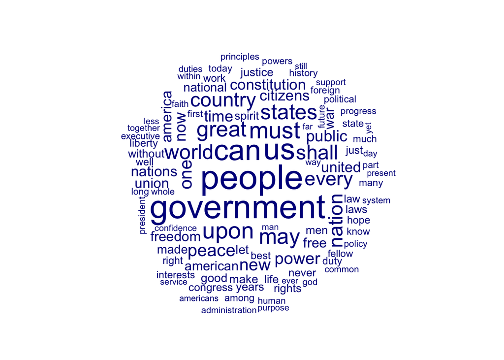

```r
textplot_wordcloud(dtm_speeches, max_words=100)
```

# 3. Sentimentanalyse mit dem Dictionary-Approach

### 3.1 Das Wörtbuch

Um eine Sentimentanalyse mit einem Wörterbuch durchzuführen, können wir die `dictionary`-Funktion von `quanteda` verwenden. Natürlich benötigen wir aber zu allererst ein Wörterbuch. Hierfür gibt es verschiedene Wege.

1. Entweder ihr erstellt ein eigenes Lexika, mit eigenen Kategorien und Themen. Der Vorteil ist, dass ihr ein Werkzeug kreieren könnt, welches passgenau auf euer spezielles Forschungsinteresse und Theoriekonzept passt. Der Nachteil ist, dass das Erstellen eines validen *und* reliablen Wörterbuches sehr arbeitsintensiv ist.
2. Oder ihr verwendet bereits bestehende Wörterbücher. Im Internet gibt es eine Vielzahl an unterschiedlichen Lexika die ihr herunterladen könnt. Zum Beispiel stellt Johann Gründl im Kontext seines Papers [Populist ideas on social media: A dictionary-based measurement of populist communication](https://journals.sagepub.com/doi/full/10.1177/1461444820976970) ein eigenes Wörterbuch vor und zum herunterladen bereit. Oder ihr ladet euch das Wörterbuch für Sentimentanalysen in deutscher Sprache von [Haselmayer/Jenny (2020)](https://data.aussda.at/dataset.xhtml?persistentId=doi:10.11587/EOPCOB) herunter.
3. Alternativ stellen auch etliche `R`-Pakete Wörterbücher bereit. Zum Beispiel enthält das Paket `SentimentAnalysis` drei verschiedene Wörterbücher: 1) `DictionaryGI` ist ein allgemeines Sentiment-Wörterbuch das auf **The General Inquirer** basiert, und 2) `DictionaryHE` und 3) `DictionaryLM` sind Wörterbücher mit einem speziellem Fokus auf Finanz- und Wirtschaftpolitik. Das Paket `qdapDictionaries` enthält ebenfalls eine Reihe von Wörterbüchern, darunter eine Liste von `positive.words` und `negative.words` und spezifische Listen für `strong.words`, `weak.words`, `power.words` und `submit.words` aus dem Harvard IV-Wörterbuch.

Ihr könnt die Wörterbücher von jedem Paket einsehen indem ihr sie installiert, in `R` ladet und die help-Page nutzt:

```r
library(SentimentAnalysis)
?DictionaryGI
names(DictionaryGI)
```

```
## [1] "negative" "positive"
```

```r
head(DictionaryGI$negative)
```

```
## [1] "abandon"     "abandonment" "abate"       "abdicate"    "abhor"
## [6] "abject"
```

```r
library(qdapDictionaries)
?positive.words
head(positive.words)
```

```
## [1] "a plus"     "abound"     "abounds"    "abundance"  "abundant"
## [6] "accessable"
```

Natürlich könnt ihr auch Wörterbücher als CSV herunterladen. Zum Beispiel gibt es das [**VADER lexicon**](https://github.com/cjhutto/vaderSentiment), welches speziell für Social Media Analysen erstellt wurde und Wörter wie "lol", "rofl" und "meh" enthält. Das Lexikon könnt ihr auf der Github-Seite von C.J. Hutto herunterladen. Dafür nutzen wir die Schritte, die ihr bereits aus dem `tidyR` Tutorial kennt:

```r
url <-  "https://raw.githubusercontent.com/cjhutto/vaderSentiment/master/vaderSentiment/vader_lexicon.txt" # Die Warnungen von R können hier übersehen werden.
vader <-  read_delim(url, col_names=c("word","sentiment", "details"),  col_types="cdc",  delim="\t") # delim = "\t" definiert wie wir die Informationen aus der Tablle separieren wollen (da die Datei eine Tabelle ist, müssen wir \t nutzen)
head(vader)
```

```
## # A tibble: 6 x 3
##   word     sentiment details
##   <chr>        <dbl> <chr>
## 1 $:            -1.5 0.80623
## 2 %)            -0.4 1.0198
## 3 %-)           -1.5 1.43178
## 4 &-:           -0.4 1.42829
## 5 &:            -0.7 0.64031
## 6 ( '}{' )       1.6 0.66332
```

Die Auswahl des Wörterbuchs hängt immer von der eigenen Forschungsfrage ab. Zum Beispiel benötigt eine Analyse von bestimmten Politikfeldern in Pressemitteilungen von politischen Parteien ein politikfeldspezifisches Wörterbuch wie es zum Beispiel [Langer/Sagarzazu (2017)](https://onlinelibrary.wiley.com/doi/abs/10.1111/psj.12119) für ihre Analyse zur britischen Finanzpolitik entwickelt haben. Egal für welches Wörterbuch ihr euch entscheidet, oder ob ihr (theoriegeleitet) ein eigenes Wörterbuch entwickelt, die zentrale Aufgabe bei dictionary-Ansätzen ist die Kontrolle, ob das Wörterbuch tatsächlich das misst, was es messen soll!